# 3 - Data Transformation - Columns

2026-03-20

```r
library(tidyverse)
library(nycflights13)
```

## Part 1 - Columns

### 1. mutate()

- Creates new columns that are derived from the existing columns
- .before = 1: argument to instead add the variables to the left side, 1 means the first column.
- .before = day: before the column day - day is a variable
- .keep = ‘used’: only keep the used columns

### 2. select()

- changes which columns are present
- select(year, month, day): by columns
- select(year:day): from year to day
- select(! year:day): select all columns except year:day
- select(where(is.character)): column data type is string
- select(starts_with(‘year’)): column name start with ‘year’
- select(ends_with(‘year’)): column name end with ‘year’
- select(contains(‘year’)): column name contain ‘year’;
- select(contains(‘year’, ignore.case=FALSE): default case-insensitive
- select(num_range(‘x’,1:3)): matches: x1, x2, and x3
- select(tail_num = tailnum): rename column name from ‘tailnum’ to ‘tail_num’, this would only show the column ‘tail_nam’

### 3. rename()

- changes the names of columns, and show all columns with the renamed one
- rename(tail_num = tailnum)

### 4. relocate()

- changes the positions of the columns
- relocate(year): will move column ‘year’ to the first column
- relocate(year, .before=day): move year to before day
- relocate(starts_with(‘arr’), .before=dep_time): move columns starts with ‘arr’ before ‘dep_time’

## Part 2 - The pip

## Part 3 - group_by()

- use group_by() to divide your dataset into groups meaningful for your analysis

### 1. summarize()

- after the group_by()
- summarize(
  - delay = mean(dep_delay, na.rm=TRUE),
  - n = n() # show total rows for each group
  - )

### 2. The slice_Functions

- slice_head(n=1): select top 1; slice_head(prop=0.1): select top 10%
- slice_tail(n=1)
- slice_max(x, n=1, *with_ties*=FALSE): with_ties = FALSE - if two have the same max, only keep one row, keeps which ever appears first in the data.
- slice_min(x, n=1)
- slice_sample(n=1)

### 3. Grouping by Multiple Variables

### 4. ungroup()

### 5. .by():

- Experimental syntax for per-operation grouping
- .by works with all verbs and has the advantage that you don’t need to use the .groups argument to suppress the grouping message or ungroup() when you’re done.

### 1. mutate()

```r
flights %>%
  mutate(
    gain = dep_delay - arr_delay, # gain by the speed
    speed = distance / air_time * 60,
    .before = 1
  )
```

```
## # A tibble: 336,776 × 21
##     gain speed  year month   day dep_time sched_dep_time dep_delay arr_time
##    <dbl> <dbl> <int> <int> <int>    <int>          <int>     <dbl>    <int>
##  1    -9  370.  2013     1     1      517            515         2      830
##  2   -16  374.  2013     1     1      533            529         4      850
##  3   -31  408.  2013     1     1      542            540         2      923
##  4    17  517.  2013     1     1      544            545        -1     1004
##  5    19  394.  2013     1     1      554            600        -6      812
##  6   -16  288.  2013     1     1      554            558        -4      740
##  7   -24  404.  2013     1     1      555            600        -5      913
##  8    11  259.  2013     1     1      557            600        -3      709
##  9     5  405.  2013     1     1      557            600        -3      838
## 10   -10  319.  2013     1     1      558            600        -2      753
## # ℹ 336,766 more rows
## # ℹ 12 more variables: sched_arr_time <int>, arr_delay <dbl>, carrier <chr>,
## #   flight <int>, tailnum <chr>, origin <chr>, dest <chr>, air_time <dbl>,
## #   distance <dbl>, hour <dbl>, minute <dbl>, time_hour <dttm>
```

```r
flights %>%
  mutate(
    gain = dep_delay - arr_delay,
    hours = air_time / 60,
    gian_per_hour = gain / hours,
    .keep='used'
  )
```

```
## # A tibble: 336,776 × 6
##    dep_delay arr_delay air_time  gain hours gian_per_hour
##        <dbl>     <dbl>    <dbl> <dbl> <dbl>         <dbl>
##  1         2        11      227    -9 3.78          -2.38
##  2         4        20      227   -16 3.78          -4.23
##  3         2        33      160   -31 2.67         -11.6
##  4        -1       -18      183    17 3.05           5.57
##  5        -6       -25      116    19 1.93           9.83
##  6        -4        12      150   -16 2.5           -6.4
##  7        -5        19      158   -24 2.63          -9.11
##  8        -3       -14       53    11 0.883         12.5
##  9        -3        -8      140     5 2.33           2.14
## 10        -2         8      138   -10 2.3           -4.35
## # ℹ 336,766 more rows
```

### 2. Select()

```r
flights %>%
  select(year, month, day) %>%
  head(5)
```

```
## # A tibble: 5 × 3
##    year month   day
##   <int> <int> <int>
## 1  2013     1     1
## 2  2013     1     1
## 3  2013     1     1
## 4  2013     1     1
## 5  2013     1     1
```

```r
flights %>%
  select(year:day) %>%
  head(5)
```

```
## # A tibble: 5 × 3
##    year month   day
##   <int> <int> <int>
## 1  2013     1     1
## 2  2013     1     1
## 3  2013     1     1
## 4  2013     1     1
## 5  2013     1     1
```

```r
flights %>%
  select(! year:day) %>%
  head(5)
```

```
## # A tibble: 5 × 16
##   dep_time sched_dep_time dep_delay arr_time sched_arr_time arr_delay carrier
##      <int>          <int>     <dbl>    <int>          <int>     <dbl> <chr>
## 1      517            515         2      830            819        11 UA
## 2      533            529         4      850            830        20 UA
## 3      542            540         2      923            850        33 AA
## 4      544            545        -1     1004           1022       -18 B6
## 5      554            600        -6      812            837       -25 DL
## # ℹ 9 more variables: flight <int>, tailnum <chr>, origin <chr>, dest <chr>,
## #   air_time <dbl>, distance <dbl>, hour <dbl>, minute <dbl>, time_hour <dttm>
```

```r
flights %>%
  select(where(is.character))
```

```
## # A tibble: 336,776 × 4
##    carrier tailnum origin dest
##    <chr>   <chr>   <chr>  <chr>
##  1 UA      N14228  EWR    IAH
##  2 UA      N24211  LGA    IAH
##  3 AA      N619AA  JFK    MIA
##  4 B6      N804JB  JFK    BQN
##  5 DL      N668DN  LGA    ATL
##  6 UA      N39463  EWR    ORD
##  7 B6      N516JB  EWR    FLL
##  8 EV      N829AS  LGA    IAD
##  9 B6      N593JB  JFK    MCO
## 10 AA      N3ALAA  LGA    ORD
## # ℹ 336,766 more rows
```

```r
flights %>%
  select(starts_with('year'))
```

```
## # A tibble: 336,776 × 1
##     year
##    <int>
##  1  2013
##  2  2013
##  3  2013
##  4  2013
##  5  2013
##  6  2013
##  7  2013
##  8  2013
##  9  2013
## 10  2013
## # ℹ 336,766 more rows
```

```r
flights %>%
  select(tail_num = tailnum)
```

```
## # A tibble: 336,776 × 1
##    tail_num
##    <chr>
##  1 N14228
##  2 N24211
##  3 N619AA
##  4 N804JB
##  5 N668DN
##  6 N39463
##  7 N516JB
##  8 N829AS
##  9 N593JB
## 10 N3ALAA
## # ℹ 336,766 more rows
```

```r
flights %>%
  rename(tail_num = tailnum)
```

```
## # A tibble: 336,776 × 19
##     year month   day dep_time sched_dep_time dep_delay arr_time sched_arr_time
##    <int> <int> <int>    <int>          <int>     <dbl>    <int>          <int>
##  1  2013     1     1      517            515         2      830            819
##  2  2013     1     1      533            529         4      850            830
##  3  2013     1     1      542            540         2      923            850
##  4  2013     1     1      544            545        -1     1004           1022
##  5  2013     1     1      554            600        -6      812            837
##  6  2013     1     1      554            558        -4      740            728
##  7  2013     1     1      555            600        -5      913            854
##  8  2013     1     1      557            600        -3      709            723
##  9  2013     1     1      557            600        -3      838            846
## 10  2013     1     1      558            600        -2      753            745
## # ℹ 336,766 more rows
## # ℹ 11 more variables: arr_delay <dbl>, carrier <chr>, flight <int>,
## #   tail_num <chr>, origin <chr>, dest <chr>, air_time <dbl>, distance <dbl>,
## #   hour <dbl>, minute <dbl>, time_hour <dttm>
```

```r
flights %>%
  relocate(time_hour, air_time)
```

```
## # A tibble: 336,776 × 19
##    time_hour           air_time  year month   day dep_time sched_dep_time
##    <dttm>                 <dbl> <int> <int> <int>    <int>          <int>
##  1 2013-01-01 05:00:00      227  2013     1     1      517            515
##  2 2013-01-01 05:00:00      227  2013     1     1      533            529
##  3 2013-01-01 05:00:00      160  2013     1     1      542            540
##  4 2013-01-01 05:00:00      183  2013     1     1      544            545
##  5 2013-01-01 06:00:00      116  2013     1     1      554            600
##  6 2013-01-01 05:00:00      150  2013     1     1      554            558
##  7 2013-01-01 06:00:00      158  2013     1     1      555            600
##  8 2013-01-01 06:00:00       53  2013     1     1      557            600
##  9 2013-01-01 06:00:00      140  2013     1     1      557            600
## 10 2013-01-01 06:00:00      138  2013     1     1      558            600
## # ℹ 336,766 more rows
## # ℹ 12 more variables: dep_delay <dbl>, arr_time <int>, sched_arr_time <int>,
## #   arr_delay <dbl>, carrier <chr>, flight <int>, tailnum <chr>, origin <chr>,
## #   dest <chr>, distance <dbl>, hour <dbl>, minute <dbl>
```

```r
flights %>%
  relocate(year:dep_time, .after = time_hour)
```

```
## # A tibble: 336,776 × 19
##    sched_dep_time dep_delay arr_time sched_arr_time arr_delay carrier flight
##             <int>     <dbl>    <int>          <int>     <dbl> <chr>    <int>
##  1            515         2      830            819        11 UA        1545
##  2            529         4      850            830        20 UA        1714
##  3            540         2      923            850        33 AA        1141
##  4            545        -1     1004           1022       -18 B6         725
##  5            600        -6      812            837       -25 DL         461
##  6            558        -4      740            728        12 UA        1696
##  7            600        -5      913            854        19 B6         507
##  8            600        -3      709            723       -14 EV        5708
##  9            600        -3      838            846        -8 B6          79
## 10            600        -2      753            745         8 AA         301
## # ℹ 336,766 more rows
## # ℹ 12 more variables: tailnum <chr>, origin <chr>, dest <chr>, air_time <dbl>,
## #   distance <dbl>, hour <dbl>, minute <dbl>, time_hour <dttm>, year <int>,
## #   month <int>, day <int>, dep_time <int>
```

```r
flights %>%
  relocate(starts_with('arr'), .before = dep_time)
```

```
## # A tibble: 336,776 × 19
##     year month   day arr_time arr_delay dep_time sched_dep_time dep_delay
##    <int> <int> <int>    <int>     <dbl>    <int>          <int>     <dbl>
##  1  2013     1     1      830        11      517            515         2
##  2  2013     1     1      850        20      533            529         4
##  3  2013     1     1      923        33      542            540         2
##  4  2013     1     1     1004       -18      544            545        -1
##  5  2013     1     1      812       -25      554            600        -6
##  6  2013     1     1      740        12      554            558        -4
##  7  2013     1     1      913        19      555            600        -5
##  8  2013     1     1      709       -14      557            600        -3
##  9  2013     1     1      838        -8      557            600        -3
## 10  2013     1     1      753         8      558            600        -2
## # ℹ 336,766 more rows
## # ℹ 11 more variables: sched_arr_time <int>, carrier <chr>, flight <int>,
## #   tailnum <chr>, origin <chr>, dest <chr>, air_time <dbl>, distance <dbl>,
## #   hour <dbl>, minute <dbl>, time_hour <dttm>
```

### Exercises

1. **Compare `dep_time`, `sched_dep_time`, and `dep_delay`. How would you expect those three numbers to be related?**

```r
flights %>%
  mutate(delay =
           (trunc(dep_time/100)  * 60 + (dep_time/100 - trunc(dep_time/100))*100) -
           (trunc(sched_dep_time/100)  * 60 + (sched_dep_time/100 - trunc(sched_dep_time/100))*100)
         ) %>%
  select(dep_time, sched_dep_time, delay, dep_delay)
```

```
## # A tibble: 336,776 × 4
##    dep_time sched_dep_time  delay dep_delay
##       <int>          <int>  <dbl>     <dbl>
##  1      517            515  2.00          2
##  2      533            529  4             4
##  3      542            540  2.00          2
##  4      544            545 -1.000        -1
##  5      554            600 -6            -6
##  6      554            558 -4            -4
##  7      555            600 -5            -5
##  8      557            600 -3            -3
##  9      557            600 -3            -3
## 10      558            600 -2            -2
## # ℹ 336,766 more rows
```

1. **Brainstorm as many ways as possible to select `dep_time`, `dep_delay`, `arr_time`, and `arr_delay`from `flights`.**

```r
flights %>%
  head(5)
```

```
## # A tibble: 5 × 19
##    year month   day dep_time sched_dep_time dep_delay arr_time sched_arr_time
##   <int> <int> <int>    <int>          <int>     <dbl>    <int>          <int>
## 1  2013     1     1      517            515         2      830            819
## 2  2013     1     1      533            529         4      850            830
## 3  2013     1     1      542            540         2      923            850
## 4  2013     1     1      544            545        -1     1004           1022
## 5  2013     1     1      554            600        -6      812            837
## # ℹ 11 more variables: arr_delay <dbl>, carrier <chr>, flight <int>,
## #   tailnum <chr>, origin <chr>, dest <chr>, air_time <dbl>, distance <dbl>,
## #   hour <dbl>, minute <dbl>, time_hour <dttm>
```

```r
flights %>%
  select(dep_time, dep_delay, arr_time, arr_delay) %>%
  head(5)
```

```
## # A tibble: 5 × 4
##   dep_time dep_delay arr_time arr_delay
##      <int>     <dbl>    <int>     <dbl>
## 1      517         2      830        11
## 2      533         4      850        20
## 3      542         2      923        33
## 4      544        -1     1004       -18
## 5      554        -6      812       -25
```

```r
flights %>%
  select((contains('dep') | contains('arr')) & !contains('sched') & !contains('carr'))
```

```
## # A tibble: 336,776 × 4
##    dep_time dep_delay arr_time arr_delay
##       <int>     <dbl>    <int>     <dbl>
##  1      517         2      830        11
##  2      533         4      850        20
##  3      542         2      923        33
##  4      544        -1     1004       -18
##  5      554        -6      812       -25
##  6      554        -4      740        12
##  7      555        -5      913        19
##  8      557        -3      709       -14
##  9      557        -3      838        -8
## 10      558        -2      753         8
## # ℹ 336,766 more rows
```

```r
select(flights, any_of(c('dep_time','dep_delay','arr_time','arr_delay','flights')))
```

```
## # A tibble: 336,776 × 4
##    dep_time dep_delay arr_time arr_delay
##       <int>     <dbl>    <int>     <dbl>
##  1      517         2      830        11
##  2      533         4      850        20
##  3      542         2      923        33
##  4      544        -1     1004       -18
##  5      554        -6      812       -25
##  6      554        -4      740        12
##  7      555        -5      913        19
##  8      557        -3      709       -14
##  9      557        -3      838        -8
## 10      558        -2      753         8
## # ℹ 336,766 more rows
```

1. **What happens if you specify the name of the same variable multiple times in a [`select()`](https://dplyr.tidyverse.org/reference/select.html) call?**

```r
flights %>%
  select('year','year') %>%
  print(width=Inf)
```

```
## # A tibble: 336,776 × 1
##     year
##    <int>
##  1  2013
##  2  2013
##  3  2013
##  4  2013
##  5  2013
##  6  2013
##  7  2013
##  8  2013
##  9  2013
## 10  2013
## # ℹ 336,766 more rows
```

What does the [`any_of()`](https://tidyselect.r-lib.org/reference/all_of.html) function do? Why might it be helpful in conjunction with this vector?

```
variables <- c("year", "month", "day", "dep_delay", "arr_delay")
```

```r
variables <- c("year", "month", "day", "dep_delay", "arr_delay")
select(flights, any_of(variables)) %>%
  print(width=Inf)
```

```
## # A tibble: 336,776 × 5
##     year month   day dep_delay arr_delay
##    <int> <int> <int>     <dbl>     <dbl>
##  1  2013     1     1         2        11
##  2  2013     1     1         4        20
##  3  2013     1     1         2        33
##  4  2013     1     1        -1       -18
##  5  2013     1     1        -6       -25
##  6  2013     1     1        -4        12
##  7  2013     1     1        -5        19
##  8  2013     1     1        -3       -14
##  9  2013     1     1        -3        -8
## 10  2013     1     1        -2         8
## # ℹ 336,766 more rows
```

Does the result of running the following code surprise you? How do the select helpers deal with upper- and lowercase by default? How can you change that default?

```r
flights |> select(contains("TIME", ignore.case=TRUE)) %>%
  print(width=50)
```

```
## # A tibble: 336,776 × 6
##    dep_time sched_dep_time arr_time sched_arr_time
##       <int>          <int>    <int>          <int>
##  1      517            515      830            819
##  2      533            529      850            830
##  3      542            540      923            850
##  4      544            545     1004           1022
##  5      554            600      812            837
##  6      554            558      740            728
##  7      555            600      913            854
##  8      557            600      709            723
##  9      557            600      838            846
## 10      558            600      753            745
## # ℹ 336,766 more rows
## # ℹ 2 more variables: air_time <dbl>,
## #   time_hour <dttm>
```

1. **Rename `air_time` to `air_time_min` to indicate units of measurement and move it to the beginning of the data frame.**

```r
flights %>%
  rename(air_time_min = air_time) %>%
  relocate(air_time_min, .before=1) %>%
  print(width=100)
```

```
## # A tibble: 336,776 × 19
##    air_time_min  year month   day dep_time sched_dep_time dep_delay arr_time
##           <dbl> <int> <int> <int>    <int>          <int>     <dbl>    <int>
##  1          227  2013     1     1      517            515         2      830
##  2          227  2013     1     1      533            529         4      850
##  3          160  2013     1     1      542            540         2      923
##  4          183  2013     1     1      544            545        -1     1004
##  5          116  2013     1     1      554            600        -6      812
##  6          150  2013     1     1      554            558        -4      740
##  7          158  2013     1     1      555            600        -5      913
##  8           53  2013     1     1      557            600        -3      709
##  9          140  2013     1     1      557            600        -3      838
## 10          138  2013     1     1      558            600        -2      753
##    sched_arr_time arr_delay carrier flight tailnum origin dest  distance  hour
##             <int>     <dbl> <chr>    <int> <chr>   <chr>  <chr>    <dbl> <dbl>
##  1            819        11 UA        1545 N14228  EWR    IAH       1400     5
##  2            830        20 UA        1714 N24211  LGA    IAH       1416     5
##  3            850        33 AA        1141 N619AA  JFK    MIA       1089     5
##  4           1022       -18 B6         725 N804JB  JFK    BQN       1576     5
##  5            837       -25 DL         461 N668DN  LGA    ATL        762     6
##  6            728        12 UA        1696 N39463  EWR    ORD        719     5
##  7            854        19 B6         507 N516JB  EWR    FLL       1065     6
##  8            723       -14 EV        5708 N829AS  LGA    IAD        229     6
##  9            846        -8 B6          79 N593JB  JFK    MCO        944     6
## 10            745         8 AA         301 N3ALAA  LGA    ORD        733     6
## # ℹ 336,766 more rows
## # ℹ 2 more variables: minute <dbl>, time_hour <dttm>
```

## The Pipe

find the fast flights to Houston’s IAH airport: you need to combine [`filter()`](https://dplyr.tidyverse.org/reference/filter.html), [`mutate()`](https://dplyr.tidyverse.org/reference/mutate.html), [`select()`](https://dplyr.tidyverse.org/reference/select.html), and [`arrange()`](https://dplyr.tidyverse.org/reference/arrange.html):

```r
flights %>%
  filter(dest == 'IAH') %>%
  mutate(speed = distance / air_time * 60) %>%
  select(year:day, dep_time, carrier, flight, speed) %>%
  arrange(desc(speed)) %>%
  print(width=Inf)
```

```
## # A tibble: 7,198 × 7
##     year month   day dep_time carrier flight speed
##    <int> <int> <int>    <int> <chr>    <int> <dbl>
##  1  2013     7     9      707 UA         226  522.
##  2  2013     8    27     1850 UA        1128  521.
##  3  2013     8    28      902 UA        1711  519.
##  4  2013     8    28     2122 UA        1022  519.
##  5  2013     6    11     1628 UA        1178  515.
##  6  2013     8    27     1017 UA         333  515.
##  7  2013     8    27     1205 UA        1421  515.
##  8  2013     8    27     1758 UA         302  515.
##  9  2013     9    27      521 UA         252  515.
## 10  2013     8    28      625 UA         559  515.
## # ℹ 7,188 more rows
```

## group_by()

```r
flights %>%
  group_by(month) %>%
  print(width=50)
```

```
## # A tibble: 336,776 × 19
## # Groups:   month [12]
##     year month   day dep_time sched_dep_time
##    <int> <int> <int>    <int>          <int>
##  1  2013     1     1      517            515
##  2  2013     1     1      533            529
##  3  2013     1     1      542            540
##  4  2013     1     1      544            545
##  5  2013     1     1      554            600
##  6  2013     1     1      554            558
##  7  2013     1     1      555            600
##  8  2013     1     1      557            600
##  9  2013     1     1      557            600
## 10  2013     1     1      558            600
## # ℹ 336,766 more rows
## # ℹ 14 more variables: dep_delay <dbl>,
## #   arr_time <int>, sched_arr_time <int>,
## #   arr_delay <dbl>, carrier <chr>, flight <int>,
## #   tailnum <chr>, origin <chr>, dest <chr>,
## #   air_time <dbl>, distance <dbl>, hour <dbl>,
## #   minute <dbl>, time_hour <dttm>
```

## summarize()

```r
flights %>%
  group_by(month) %>%
  summarize(
    avg_delay = mean(dep_delay, na.rm=TRUE)
  ) %>%
  print(width=Inf)
```

```
## # A tibble: 12 × 2
##    month avg_delay
##    <int>     <dbl>
##  1     1     10.0
##  2     2     10.8
##  3     3     13.2
##  4     4     13.9
##  5     5     13.0
##  6     6     20.8
##  7     7     21.7
##  8     8     12.6
##  9     9      6.72
## 10    10      6.24
## 11    11      5.44
## 12    12     16.6
```

```r
flights %>%
  group_by(month) %>%
  summarize(
    delay = mean(dep_delay, na.rm=TRUE),
    n = n()
  ) %>%
  print(width = Inf)
```

```
## # A tibble: 12 × 3
##    month delay     n
##    <int> <dbl> <int>
##  1     1 10.0  27004
##  2     2 10.8  24951
##  3     3 13.2  28834
##  4     4 13.9  28330
##  5     5 13.0  28796
##  6     6 20.8  28243
##  7     7 21.7  29425
##  8     8 12.6  29327
##  9     9  6.72 27574
## 10    10  6.24 28889
## 11    11  5.44 27268
## 12    12 16.6  28135
```

## The slice_Functions

```r
flights %>%
  group_by(dest) %>%
  slice_max(arr_delay, n=1, with_ties=FALSE) %>%
  relocate(dest, arr_delay) %>%
  print(width=60)
```

```
## # A tibble: 105 × 19
## # Groups:   dest [105]
##    dest  arr_delay  year month   day dep_time sched_dep_time
##    <chr>     <dbl> <int> <int> <int>    <int>          <int>
##  1 ABQ         153  2013     7    22     2145           2007
##  2 ACK         221  2013     7    23     1139            800
##  3 ALB         328  2013     1    25      123           2000
##  4 ANC          39  2013     8    17     1740           1625
##  5 ATL         895  2013     7    22     2257            759
##  6 AUS         349  2013     7    10     2056           1505
##  7 AVL         228  2013     8    13     1156            832
##  8 BDL         266  2013     2    21     1728           1316
##  9 BGR         238  2013    12     1     1504           1056
## 10 BHM         291  2013     4    10       25           1900
## # ℹ 95 more rows
## # ℹ 12 more variables: dep_delay <dbl>, arr_time <int>,
## #   sched_arr_time <int>, carrier <chr>, flight <int>,
## #   tailnum <chr>, origin <chr>, air_time <dbl>,
## #   distance <dbl>, hour <dbl>, minute <dbl>,
## #   time_hour <dttm>
```

## Grouping by multiple variables

```r
daily <- flights %>%
  group_by(year, month, day)
daily %>%
  print(width=60)
```

```
## # A tibble: 336,776 × 19
## # Groups:   year, month, day [365]
##     year month   day dep_time sched_dep_time dep_delay
##    <int> <int> <int>    <int>          <int>     <dbl>
##  1  2013     1     1      517            515         2
##  2  2013     1     1      533            529         4
##  3  2013     1     1      542            540         2
##  4  2013     1     1      544            545        -1
##  5  2013     1     1      554            600        -6
##  6  2013     1     1      554            558        -4
##  7  2013     1     1      555            600        -5
##  8  2013     1     1      557            600        -3
##  9  2013     1     1      557            600        -3
## 10  2013     1     1      558            600        -2
## # ℹ 336,766 more rows
## # ℹ 13 more variables: arr_time <int>,
## #   sched_arr_time <int>, arr_delay <dbl>, carrier <chr>,
## #   flight <int>, tailnum <chr>, origin <chr>, dest <chr>,
## #   air_time <dbl>, distance <dbl>, hour <dbl>,
## #   minute <dbl>, time_hour <dttm>
```

```r
daily %>%
  summarize(n = n(),
            .groups = 'drop_last') %>%
  print(width = 50)
```

```
## # A tibble: 365 × 4
## # Groups:   year, month [12]
##     year month   day     n
##    <int> <int> <int> <int>
##  1  2013     1     1   842
##  2  2013     1     2   943
##  3  2013     1     3   914
##  4  2013     1     4   915
##  5  2013     1     5   720
##  6  2013     1     6   832
##  7  2013     1     7   933
##  8  2013     1     8   899
##  9  2013     1     9   902
## 10  2013     1    10   932
## # ℹ 355 more rows
```

## Ungrouping

```r
daily %>%
  ungroup()
```

```
## # A tibble: 336,776 × 19
##     year month   day dep_time sched_dep_time dep_delay arr_time sched_arr_time
##    <int> <int> <int>    <int>          <int>     <dbl>    <int>          <int>
##  1  2013     1     1      517            515         2      830            819
##  2  2013     1     1      533            529         4      850            830
##  3  2013     1     1      542            540         2      923            850
##  4  2013     1     1      544            545        -1     1004           1022
##  5  2013     1     1      554            600        -6      812            837
##  6  2013     1     1      554            558        -4      740            728
##  7  2013     1     1      555            600        -5      913            854
##  8  2013     1     1      557            600        -3      709            723
##  9  2013     1     1      557            600        -3      838            846
## 10  2013     1     1      558            600        -2      753            745
## # ℹ 336,766 more rows
## # ℹ 11 more variables: arr_delay <dbl>, carrier <chr>, flight <int>,
## #   tailnum <chr>, origin <chr>, dest <chr>, air_time <dbl>, distance <dbl>,
## #   hour <dbl>, minute <dbl>, time_hour <dttm>
```

## .by

```r
flights %>%
  summarize(
    delay = mean(dep_delay, na.rm=TRUE),
    n = n(),
    .by = month
  )
```

```
## # A tibble: 12 × 3
##    month delay     n
##    <int> <dbl> <int>
##  1     1 10.0  27004
##  2    10  6.24 28889
##  3    11  5.44 27268
##  4    12 16.6  28135
##  5     2 10.8  24951
##  6     3 13.2  28834
##  7     4 13.9  28330
##  8     5 13.0  28796
##  9     6 20.8  28243
## 10     7 21.7  29425
## 11     8 12.6  29327
## 12     9  6.72 27574
```

```r
flights %>%
  summarize(
    delay = mean(dep_delay, na.rm=TRUE),
    n = n(),
    .by = c(origin, dest)
  )
```

```
## # A tibble: 224 × 4
##    origin dest  delay     n
##    <chr>  <chr> <dbl> <int>
##  1 EWR    IAH   11.8   3973
##  2 LGA    IAH    9.06  2951
##  3 JFK    MIA    9.34  3314
##  4 JFK    BQN    6.67   599
##  5 LGA    ATL   11.4  10263
##  6 EWR    ORD   14.6   6100
##  7 EWR    FLL   13.5   3793
##  8 LGA    IAD   16.7   1803
##  9 JFK    MCO   10.6   5464
## 10 LGA    ORD   10.7   8857
## # ℹ 214 more rows
```

## Exercises

```r
flights
```

```
## # A tibble: 336,776 × 19
##     year month   day dep_time sched_dep_time dep_delay arr_time sched_arr_time
##    <int> <int> <int>    <int>          <int>     <dbl>    <int>          <int>
##  1  2013     1     1      517            515         2      830            819
##  2  2013     1     1      533            529         4      850            830
##  3  2013     1     1      542            540         2      923            850
##  4  2013     1     1      544            545        -1     1004           1022
##  5  2013     1     1      554            600        -6      812            837
##  6  2013     1     1      554            558        -4      740            728
##  7  2013     1     1      555            600        -5      913            854
##  8  2013     1     1      557            600        -3      709            723
##  9  2013     1     1      557            600        -3      838            846
## 10  2013     1     1      558            600        -2      753            745
## # ℹ 336,766 more rows
## # ℹ 11 more variables: arr_delay <dbl>, carrier <chr>, flight <int>,
## #   tailnum <chr>, origin <chr>, dest <chr>, air_time <dbl>, distance <dbl>,
## #   hour <dbl>, minute <dbl>, time_hour <dttm>
```

```r
flights %>%
  group_by(carrier) %>%
  summarize(
    delay = mean(dep_delay, na.rm=TRUE)
  ) %>%
  slice_max(delay)
```

```
## # A tibble: 1 × 2
##   carrier delay
##   <chr>   <dbl>
## 1 F9       20.2
```

1. **Find the flights that are most delayed upon departure from each destination.**

```r
flights %>%
  group_by(dest) %>%
  slice_max(dep_delay, n = 1, with_ties=FALSE) %>%
  select(dest, carrier, flight, dep_delay) %>%
  arrange(desc(dep_delay))
```

```
## # A tibble: 105 × 4
## # Groups:   dest [105]
##    dest  carrier flight dep_delay
##    <chr> <chr>    <int>     <dbl>
##  1 HNL   HA          51      1301
##  2 CMH   MQ        3535      1137
##  3 ORD   MQ        3695      1126
##  4 SFO   AA         177      1014
##  5 CVG   MQ        3075      1005
##  6 TPA   DL        2391       960
##  7 MSP   DL        2119       911
##  8 PDX   DL        2007       899
##  9 ATL   DL        2047       898
## 10 MIA   AA         172       896
## # ℹ 95 more rows
```

1. **How do delays vary over the course of the day. Illustrate your answer with a plot.**

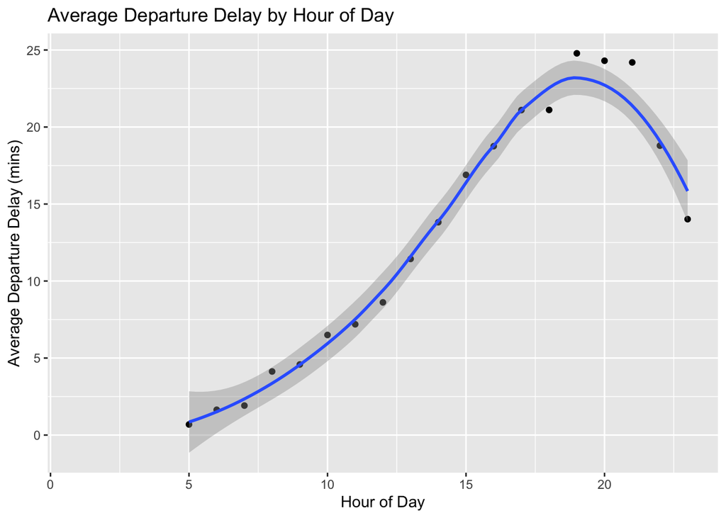

```r
flights %>%
  group_by(hour) %>%
  summarize(
    delay = mean(dep_delay, na.rm=TRUE)
  ) %>%
  ggplot(aes(x = hour, y = delay)) +
  geom_point()+
  geom_smooth()+
  labs(
    title = 'Average Departure Delay by Hour of Day',
    x = 'Hour of Day',
    y = 'Average Departure Delay (mins)'
  )
```

1. **Explain what [`count()`](https://dplyr.tidyverse.org/reference/count.html) does in terms of the dplyr verbs you just learned. What does the `sort` argument to [`count()`](https://dplyr.tidyverse.org/reference/count.html) do?**

```r
flights %>%
  count(year, month, sort = TRUE) %>%
  print(width=Inf)
```

```
## # A tibble: 12 × 3
##     year month     n
##    <int> <int> <int>
##  1  2013     7 29425
##  2  2013     8 29327
##  3  2013    10 28889
##  4  2013     3 28834
##  5  2013     5 28796
##  6  2013     4 28330
##  7  2013     6 28243
##  8  2013    12 28135
##  9  2013     9 27574
## 10  2013    11 27268
## 11  2013     1 27004
## 12  2013     2 24951
```

```r
df <- tibble(
  x = 1:5,
  y = c("a", "b", "a", "a", "b"),
  z = c("K", "K", "L", "L", "K")
)
```

```r
df
```

```
## # A tibble: 5 × 3
##       x y     z
##   <int> <chr> <chr>
## 1     1 a     K
## 2     2 b     K
## 3     3 a     L
## 4     4 a     L
## 5     5 b     K
```

```r
df %>%
  group_by(y)
```

```
## # A tibble: 5 × 3
## # Groups:   y [2]
##       x y     z
##   <int> <chr> <chr>
## 1     1 a     K
## 2     2 b     K
## 3     3 a     L
## 4     4 a     L
## 5     5 b     K
```

```r
df %>%
  arrange(y)
```

```
## # A tibble: 5 × 3
##       x y     z
##   <int> <chr> <chr>
## 1     1 a     K
## 2     3 a     L
## 3     4 a     L
## 4     2 b     K
## 5     5 b     K
```

```r
df %>%
  group_by(y) %>%
  summarize(mean_x = mean(x))
```

```
## # A tibble: 2 × 2
##   y     mean_x
##   <chr>  <dbl>
## 1 a       2.67
## 2 b       3.5
```

```r
df %>%
  group_by(y, z) %>%
  summarize(mean_x = mean(x))
```

[output not shown]

```
## # A tibble: 3 × 3
## # Groups:   y [2]
##   y     z     mean_x
##   <chr> <chr>  <dbl>
## 1 a     K        1
## 2 a     L        3.5
## 3 b     K        3.5
```

```r
df %>%
  group_by(y, z) %>%
  summarize(mean_x = mean(x), .groups = 'drop')
```

```
## # A tibble: 3 × 3
##   y     z     mean_x
##   <chr> <chr>  <dbl>
## 1 a     K        1
## 2 a     L        3.5
## 3 b     K        3.5
```

```r
df %>%
  group_by(y, z) %>%
  summarize(mean_x = mean(x), .groups = 'drop')
```

```
## # A tibble: 3 × 3
##   y     z     mean_x
##   <chr> <chr>  <dbl>
## 1 a     K        1
## 2 a     L        3.5
## 3 b     K        3.5
```

```r
df %>%
  group_by(y, z) %>%
  summarize(mean_x = mean(x))
```

[output not shown]

```
## # A tibble: 3 × 3
## # Groups:   y [2]
##   y     z     mean_x
##   <chr> <chr>  <dbl>
## 1 a     K        1
## 2 a     L        3.5
## 3 b     K        3.5
```

```r
df %>%
  group_by(y, z) %>%
  mutate(mean_x = mean(x))
```

```
## # A tibble: 5 × 4
## # Groups:   y, z [3]
##       x y     z     mean_x
##   <int> <chr> <chr>  <dbl>
## 1     1 a     K        1
## 2     2 b     K        3.5
## 3     3 a     L        3.5
## 4     4 a     L        3.5
## 5     5 b     K        3.5
```

## Case Study: Aggregates and Sample Size

```r
batters <- Lahman::Batting |>
  group_by(playerID) |>
  summarize(
    performance = sum(H, na.rm = TRUE) / sum(AB, na.rm = TRUE),
    n = sum(AB, na.rm = TRUE)
  )
batters
```

```
## # A tibble: 20,985 × 3
##    playerID  performance     n
##    <chr>           <dbl> <int>
##  1 aardsda01      0          4
##  2 aaronha01      0.305  12364
##  3 aaronto01      0.229    944
##  4 aasedo01       0          5
##  5 abadan01       0.0952    21
##  6 abadfe01       0.111      9
##  7 abadijo01      0.224     49
##  8 abbated01      0.254   3044
##  9 abbeybe01      0.169    225
## 10 abbeych01      0.281   1756
## # ℹ 20,975 more rows
```

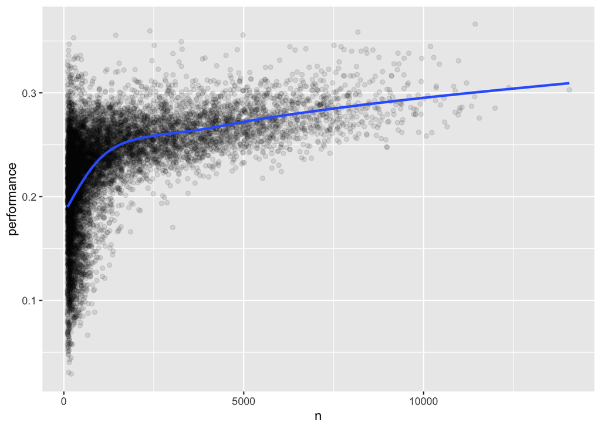

```r
batters %>%
  filter(n > 100) %>%
  ggplot(aes(x = n, y = performance)) +
  geom_point(alpha = 1/ 10) +
  geom_smooth(se = FALSE)
```